# 複雑系としての治療関係

LLM、心理ネットワーク、ダイナミカル・システム、能動的推論

## 国里愛彦（くにさと よしひこ）

- 専修大学人間科学部心理学科 教授
- 専門：計算論的精神医学、認知行動療法
- COI開示：発表に関連し、開示すべきCOI関係にある企業などはありません。

## 治療同盟とアウトカムの関係

- 心理療法全般：$r\fallingdotseq.27$(Horvath et al. 2011; Flückiger et al. 2018)
- 成人うつ病CBT：$r=.26$(Cameron, Rodgers, and Dagnan 2018)

> 頑健な**小～中程度の関連**があり、治療同盟はアウトカムに影響すると考えられる

## 治療同盟を扱う際の留意点

- 治療同盟は**時間的に変化**し、関係において**亀裂と修復**が重要(Eubanks, Muran, and Safran 2018)
- 治療同盟では**ThとClでずれ**が生じることがあり、Th-Clともに治療同盟が高いと思った次の回で症状が低くなる(Whelen, Ezawa, and Strunk 2023)
- 認知行動療法での治療関係は技法の前提であるだけでなく、**技法の実施過程に関係が埋め込まれる**(N. Kazantzis and Dobson 2022; Nikolaos. Kazantzis and Dobson 2024)

> ①時間的に変化する関係を捉える、②Th-Clの同期を検討する、③治療同盟と技法による症状改善の線形の関係だけでなく相互作用を考慮する

## 最近の機械学習・自然言語処理を用いた研究

- セッション後の質問紙評価ではなく、対話データから治療同盟を検討 (Aafjes-van Doorn et al. 2021; Flemotomos et al. 2021)

| 研究 | 対象者／データ／手法 | 結果 |
| --- | --- | --- |
| Li et al. (2024) | 82クライエント；中国語テキスト相談859セッション；GPT-4 | GPT-4の評定は、人間のWorking Alliance Inventory評定と中程度に一致（$r=.50$） |
| Lin et al. (2025) | 英語の心理療法逐語録958セッション；Sentence-BERT＋WA-LSTM | WAI項目との意味類似度から、診断群ごとに異なる二者の同盟の変化を可視化 |
| Eliassaf et al. (2026) | 68クライエント；ヘブライ語逐語録872セッション；AlephBERT | 技法の多様性が普段より高い回ほど、WAIが高い |
| Li et al. (2026) | 82クライエント；中国語テキスト相談793セッション；LLaMA-3.1-8B | 患者WAIとの相関は目標$.52$、課題$.50$、絆$.46$で、治療者評定より高かった |
| Chen et al. (2026) | 37クライエント；英語の心理療法逐語録1,610セッション；GPT-4o-mini＋SEM | 治療者の共感と探索は、直後の患者の自己開示増加を予測した |

## LLMを用いた研究について

- LLMを用いた治療同盟研究が進んでいる。セラピスト評価よりもLLM評価のほうがクライエント評価と関連するという結果も出てきている。

> 時間的コストをかけずにセッションの内容をそのまま評価できる
- 現状では主にテキスト情報のみを扱っている。ただ、データをリッチにするほどプライバシーの保護の問題も出てくる。

> 声色、視線、生理指標などのマルチモーダルなデータで検討した研究が必要。ローカルLLMなどのプライバシーの保護が可能な方法を使う。

## 心理ネットワーク

- 集団平均の単純媒介モデルから**個人ごとに異なる相互作用ネットワークを推定し介入標的を選ぶ**方向へ(Hofmann, Curtiss, and Hayes 2020)
- 心理ネットワークモデルでは、変数間の関係性をネットワークとして可視化できる(Isvoranu et al. 2022)。個人の時系列データに適用すると**経時的ネットワーク**と**同時性ネットワーク**が推定できる。

> 時間を考慮にいれた変数間のネットワークの可視化ができ、ケースフォーミュレーションに活用できる  
> プロセス・ベースド・セラピーへの展開

## 治療関係を心理ネットワークから検討

感情焦点化療法を受けた123名の初回から5回目までのデータで３つのネットワークを検討(Řiháček et al. 2024)

- **自己についての新しい発見** → 次回の安堵、進展、他者理解、治療関係
- **体験から距離を取ること** → 次回の治療関係、安堵

> 治療関係→治療的変化よりは、治療的変化→治療関係という時間的な方向性を示した。  
> 認知行動療法ではどうか？

## Th-Cl間のネットワークの検討

- 異性愛カップルデータにグラフィカルML-VARモデルを用いて**二者間の感情ネットワーク**を調べる方法がある(Bar-Kalifa and Sened 2020)
- 個人心理療法（主に短期力動的心理療法）のTh-Cl関係にも適用したところ、治療反応群の方が前のセッション時の感情が次のセッション時の感情に影響しにくく、かつ**セッション時のTh-Clの感情が共変動しやすい**(Bar-Kalifa and Atzil-Slonim 2020)

> Cl個人内ネットワークだけでなく、Thも組み込んだネットワークによる治療関係の検討も可能に  
> 認知行動療法ではどうか？

## ダイナミカル・システム

### ダイナミカル・システムとは？

- **複数の心理状態や行動が時間とともに相互作用し、その相互作用によって全体のパターンが変化・安定化していくシステムを扱う枠組み**（微分方程式でモデル化）
- 心理療法を時間とともに自己組織化する開放系として捉え、変動を誤差だけでなく相転移の情報としてみる(Gelo and Salvatore 2016)

| 安定した不適応 | → 脱安定化 | → 臨界揺らぎ | → 再組織化 |
| --- | --- | --- | --- |
| アトラクター | 介入・予測誤差 | 停滞・変動増大 | 新しいパターン |

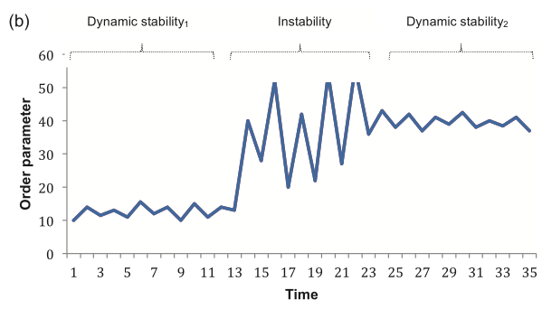

## ダイナミカル・システムの限界と展開

- ダイナミカル・システムの歴史は古く、自己組織化、アトラクター、相転移、同期など、心理療法の非線形な変化を記述する言葉を提供してきた(Klocek, Premus, and Řiháček 2024)
- 微分方程式を用いるため、どうしても理論駆動的になり、**データとの直接的な接続が難しい**(Klocek, Premus, and Řiháček 2024)。**メタファー止まり**という批判も。

> 微分方程式モデルと心理ネットワークモデルとを関連づけた研究が必要(理論モデルとデータモデルの連結)。深層学習などで微分方程式モデルを直接データにフィットさせる方法も有望だろう。

## 自由エネルギー原理

- **自由エネルギー最小化**から知覚や行動を統一的に説明する理論(Friston 2010)
- 外部状態 $s^*$ は直接観測できないので、生成モデルを用いて感覚入力$o$から外部状態を推測する(**知覚**)
- 外界の状態にも働きかけることで信念の確信度を高めたり好ましい結果を得ようとする(**行動**)

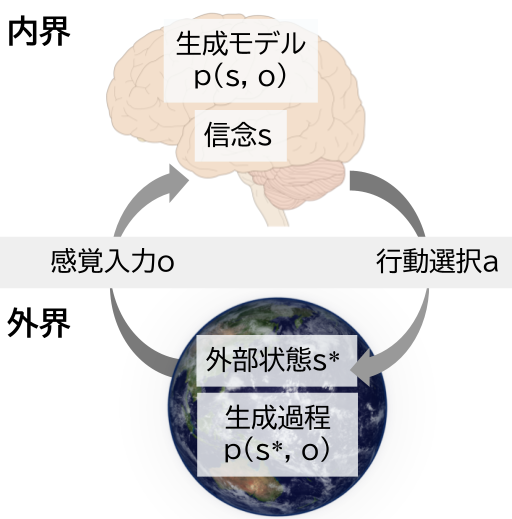

> 自由ネルギー原理基づく能動的推論モデルでモデル化

## 治療関係の能動的推論モデル

- 治療同盟は**ClとThが互いの生成モデルを調整する**階層的モデル(Krupnik 2023)
- **治療同盟は不確実性を安全に保持する「驚きに対する緩衝材」**(Hubatka and Řiháček 2025)

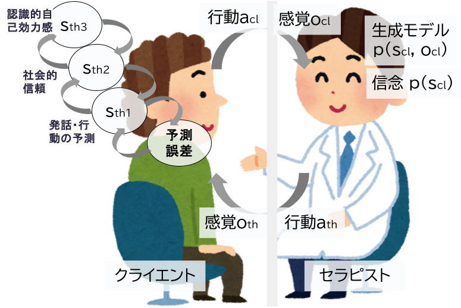

## まとめ

> LLMと心理ネットワーク分析はデータ駆動的に検討するのに使える。

> ダイナミカル・システムと能動的推論モデルは理論駆動的に検討するのに使える。  
> 能動的推論はより統合的な視座を提供でき、データフィットもできつつある。

> データ駆動研究と理論駆動研究の接地面こそが治療関係研究のフロンティアになる？

## 引用文献

Aafjes-van Doorn, Katie, Céline Kamsteeg, Jordan Bate, and Marc Aafjes. 2021. “A Scoping Review of Machine Learning in Psychotherapy Research.” *Psychotherapy Research* 31 (1): 92–116. https://doi.org/10.1080/10503307.2020.1808729.

Bar-Kalifa, Eran, and Dana Atzil-Slonim. 2020. “Intrapersonal and Interpersonal Emotional Networks and Their Associations with Treatment Outcome.” *Journal of Counseling Psychology* 67 (5): 580–94.

Bar-Kalifa, Eran, and Haran Sened. 2020. “Using Network Analysis for Examining Interpersonal Emotion Dynamics.” *Multivariate Behavioral Research* 55 (2): 211–30.

Cameron, Sarah Kate, Jacqui Rodgers, and Dave Dagnan. 2018. “The Relationship Between the Therapeutic Alliance and Clinical Outcomes in Cognitive Behaviour Therapy for Adults with Depression: A Meta-Analytic Review.” *Clinical Psychology & Psychotherapy* 25 (3): 446–56. https://doi.org/10.1002/cpp.2180.

Chen, Angela, Siwei Jin, Canwen Wang, Holly Swartz, Tongshuang Wu, Robert E. Kraut, and Haiyi Zhu. 2026. “Modeling of Therapist–Client Dynamics in Psychotherapy Using LLM-Based Assessments: An Empirical Study.” https://doi.org/10.48550/arXiv.2602.12450.

Eliassaf, Amir, Yael Bar-Shachar, Aya Shamir, and Dana Atzil-Slonim. 2026. “Leveraging Large Language Models to Assess Therapeutic Technique Diversity and Its Associations with the Therapeutic Alliance and Outcome.” *Psychotherapy Research*, 1–14. https://doi.org/10.1080/10503307.2026.2689633.

Eubanks, Catherine F., J. Christopher Muran, and Jeremy D. Safran. 2018. “Alliance Rupture Repair: A Meta-Analysis.” *Psychotherapy* 55 (4): 508–19. https://doi.org/10.1037/pst0000185.

Flemotomos, Nikolaos, Victor R. Martinez, Zhuohao Chen, Torrey A. Creed, David C. Atkins, and Shrikanth Narayanan. 2021. “Automated Quality Assessment of Cognitive Behavioral Therapy Sessions Through Highly Contextualized Language Representations.” *PLOS ONE* 16 (10): e0258639. https://doi.org/10.1371/journal.pone.0258639.

Flückiger, Christoph, A. C. Del Re, Bruce E. Wampold, and Adam O. Horvath. 2018. “The Alliance in Adult Psychotherapy: A Meta-Analytic Synthesis.” *Psychotherapy* 55 (4): 316–40. https://doi.org/10.1037/pst0000172.

Friston, Karl. 2010. “The Free-Energy Principle: A Unified Brain Theory?” *Nature Reviews. Neuroscience* 11 (2): 127–38.

Gelo, Omar Carlo Gioacchino, and Sergio Salvatore. 2016. “A Dynamic Systems Approach to Psychotherapy: A Meta-Theoretical Framework for Explaining Psychotherapy Change Processes.” *Journal of Counseling Psychology* 63 (4): 379–95. https://doi.org/10.1037/cou0000150.

Hofmann, Stefan G., Joshua E. Curtiss, and Steven C. Hayes. 2020. “Beyond Linear Mediation: Toward a Dynamic Network Approach to Study Treatment Processes.” *Clinical Psychology Review* 76: 101824. https://doi.org/10.1016/j.cpr.2020.101824.

Horvath, Adam O, A C Del Re, Christoph Flückiger, and Dianne Symonds. 2011. “Alliance in Individual Psychotherapy.” *Psychotherapy (Chicago, Ill.)* 48 (1): 9–16. https://doi.org/10.1037/a0022186.

Hubatka, Petra, and Tomáš Řiháček. 2025. “Common Factors Viewed Through the Lens of the Active Inference Framework: A Mapping Review.” *Journal of Psychotherapy Integration* 35 (1): 68–83. https://doi.org/10.1037/int0000350.

Isvoranu, Adela-Maria, Sacha Epskamp, Lourens Waldorp, and Denny Borsboom, eds. 2022. *Network Psychometrics with R: A Guide for Behavioral and Social Scientists*. London, England: Routledge.

Kazantzis, Nikolaos., and Keith S. Dobson. 2024. “Therapeutic Relationships in Cognitive Behavioral Therapy: Agreement in Alliance, Client Factors, Therapist Factors, and CBT Specific Processes.” *Psychotherapy Research* 34 (1): 1–3. https://doi.org/10.1080/10503307.2023.2290061.

Kazantzis, Nikolaos, and Keith S. Dobson. 2022. “Therapeutic Relationships in Cognitive Behavioral Therapy: Theory and Recent Research.” *Psychotherapy Research* 32 (8): 969–71. https://doi.org/10.1080/10503307.2022.2124047.

Klocek, Adam, Jan Premus, and Tomáš Řiháček. 2024. “Applying Dynamic Systems Theory and Complexity Theory Methods in Psychotherapy Research: A Systematic Literature Review.” *Psychotherapy Research* 34 (6): 828–44. https://doi.org/10.1080/10503307.2023.2252169.

Krupnik, Valery. 2023. “The Therapeutic Alliance as Active Inference: The Role of Trust and Self-Efficacy.” *Journal of Contemporary Psychotherapy* 53 (3): 207–15. https://doi.org/10.1007/s10879-022-09576-1.

Li, Anqi, Yu Lu, Nirui Song, Shuai Zhang, Lizhi Ma, and Zhenzhong Lan. 2024. “Understanding the Therapeutic Relationship Between Counselors and Clients in Online Text-Based Counseling Using LLMs.” In *Findings of the Association for Computational Linguistics: EMNLP 2024*, 1280–1303. Miami, Florida, USA: Association for Computational Linguistics. https://doi.org/10.18653/v1/2024.findings-emnlp.69.

Li, Anqi, Chenxiao Wang, Yu Lu, Renjun Xu, Lizhi Ma, and Zhenzhong Lan. 2026. “CARE: An Explainable Computational Framework for Assessing Client-Perceived Therapeutic Alliance Using Large Language Models.” https://doi.org/10.48550/arXiv.2602.20648.

Lin, Baihan, Djallel Bouneffouf, Yulia Landa, Rachel Jespersen, Cheryl Corcoran, and Guillermo Cecchi. 2025. “COMPASS: Computational Mapping of Patient–Therapist Alliance Strategies with Language Modeling.” *Translational Psychiatry* 15 (1): 166. https://doi.org/10.1038/s41398-025-03379-3.

Řiháček, Tomáš, Robert Elliott, Jesse Owen, and Michaela Ladmanová. 2024. “The Structure and Dynamics of Client Session Reactions: An Exploratory Longitudinal Network Analysis.” *Journal of Psychotherapy Integration* 34 (2): 174–89. https://doi.org/10.1037/int0000331.

Whelen, Megan L., Iony D. Ezawa, and Daniel R. Strunk. 2023. “Congruence in Patient and Therapist-Rated Alliance Predicts Subsequent Depressive Symptoms in Cognitive Behavioral Therapy for Depression.” *Psychotherapy Research* 33 (6): 719–28. https://doi.org/10.1080/10503307.2022.2156304.